# Bioinformatics

# Astract

In this project we analyzed the Novikoff hepatoma desease,with the aim of carrying on a network medicine analysis. We started with the data collection,exploring the related information sources (DisGeNet datasets), collecting the the list of human genes of interest and finally scraping protein-protein interaction data. Proceeding with the data analysis we created the graph, we calculated the main network measures for the disease interactome and we applied the MCL algorithm to find out putative disease modules with hypergeometric test and DIAMOnD tool.

## Disease Description: Hepatoma

Novikoff hepatoma mitochondria were studied with regard to their functional and structural organization. The activities of cytochrome oxidase and malate dehydrogenase in mitochondria purified on sucrose gradients were similar in organelles derived from normal liver and hepatoma tissue. However, the activities of reduced nicotinamide adenine dinucleotide oxidase and succinate oxidase in hepatoma mitochondria were reduced to only 10 and 35%, respectively, of the activities in liver mitochondria. Also, monoamine oxidase and rotenone-insensitive reduced nicotinamide adenine dinucleotide-cytochrome c reductase (enzymes localized in the outer mitochondrial membrane) have significantly reduced activities in hepatoma mitochondria. The structural changes in hepatoma mitochondria might be correlated with differences in the banding patterns of liver and hepatoma mitochondria in sucrose gradients. While liver mitochondria banded sharply at a density of 1.187 g/ml, as evidenced by marker enzyme activity and protein assay, hepatoma mitochondria were heterogeneous, banding over a density range of 1.144 to 1.161 g/ml.

## Seed genes

### Table visualization

geneId

geneSymbol

uniprotAC

proteinName

notes

174

AFP

P02771

Alpha-fetoprotein

212

ALAS2

P22557

5-aminolevulinate synthase

337

APOA4

P06727

Apolipoprotein A-IV

344

APOC2

P02655

Apolipoprotein C-II

355

FAS

P25445

Tumor necrosis factor receptor superfamily member 6

538

ATP7A

Q04656

Copper-transporting ATPase 1

540

ATP7B

P35670

Copper-transporting ATPase 2

578

BAK1

Q16611

Bcl-2 homologous antagonist/killer

595

CCND1

P24385

G1/S-specific cyclin-D1

596

BCL2

P10415

Apoptosis regulator Bcl-2

598

BCL2L1

Q07817

Bcl-2-like protein 1

967

CD63

P08962

CD63 antigen

999

CDH1

P12830

Cadherin-1

1317

SLC31A1

O15431

High affinity copper uptake protein 1

1356

CP

P00450

Ceruloplasmin

1499

CTNNB1

P35222

Catenin beta-1

1544

CYP1A2

P05177

Cytochrome P450 1A2

1571

CYP2E1

P05181

Cytochrome P450 2E1

2026

ENO2

P09104

Gamma-enolase

2161

F12

P00748

Coagulation factor XII

2305

FOXM1

Q08050

Forkhead box protein M1

2705

GJB1

P08034

Gap junction beta-1 protein

2752

GLUL

P15104

Glutamine synthetase

2922

GRP

P07492

Gastrin-releasing peptide

2950

GSTP1

P09211

Glutathione S-transferase P

3082

HGF

P14210

Hepatocyte growth factor

3265

HRAS

P01112

GTPase HRas

3569

IL6

P05231

Interleukin-6

3717

JAK2

O60674

Tyrosine-protein kinase JAK2

3791

KDR

P35968

Vascular endothelial growth factor receptor 2

3845

KRAS

P01116

GTPase KRas

4233

MET

P08581

Hepatocyte growth factor receptor

4240

MFGE8

Q08431

Lactadherin

4283

CXCL9

Q07325

C-X-C motif chemokine 9

4313

MMP2

P08253

72 kDa type IV collagenase

4609

MYC

P01106

Myc proto-oncogene protein

5052

PRDX1

Q06830

Peroxiredoxin-1

5371

PML

P29590

Protein PML

5471

PPAT

Q06203

Amidophosphoribosyltransferase

5594

MAPK1

P28482

Mitogen-activated protein kinase 1

5595

MAPK3

P27361

Mitogen-activated protein kinase 3

5925

RB1

P06400

Retinoblastoma-associated protein

6364

CCL20

P78556

C-C motif chemokine 20

6659

SOX4

Q06945

Transcription factor SOX-4

6696

SPP1

P10451

Osteopontin

6713

SQLE

Q14534

Squalene monooxygenase

6774

STAT3

P40763

Signal transducer and activator of transcription 3

7010

TEK

Q02763

Angiopoietin-1 receptor

7039

TGFA

P01135

Protransforming growth factor alpha [Cleaved into: Transforming growth factor alpha

7040

TGFB1

P01137

Transforming growth factor beta-1 proprotein [Cleaved into: Latency-associated peptide

7083

TK1

P04183

Thymidine kinase

7124

TNF

P01375

Tumor necrosis factor

7157

TP53

P04637

Cellular tumor antigen p53

8517

IKBKG

Q9Y6K9

NF-kappa-B essential modulator

8651

SOCS1

O15524

Suppressor of cytokine signaling 1

8795

TNFRSF10B

O14763

Tumor necrosis factor receptor superfamily member 10B

8848

TSC22D1

Q15714

TSC22 domain family protein 1

9104

RGN

Q15493

Regucalcin

9970

NR1I3

Q14994

Nuclear receptor subfamily 1 group I member 3

22800

RRAS2

P62070

Ras-related protein R-Ras2

23582

CCNDBP1

O95273

Cyclin-D1-binding protein 1

27113

BBC3

Q9BXH1

Bcl-2-binding component 3

219972

MPEG1

Q2M385

Macrophage-expressed gene 1 protein

283120

H19

Not in Uniprot.

406884

MIRLET7B

Not in Uniprot.

406886

MIRLET7D

Not in Uniprot.

406887

MIRLET7E

Not in Uniprot.

406891

MIRLET7I

Not in Uniprot.

406902

MIR10A

Not in Uniprot.

406910

MIR125A

Not in Uniprot.

406937

MIR145

Not in Uniprot.

406953

MIR18A

Not in Uniprot.

406957

MIR181C

Not in Uniprot.

406959

MIR183

Not in Uniprot.

406962

MIR186

Not in Uniprot.

406971

MIR195

Not in Uniprot.

406984

MIR200B

Not in Uniprot.

406989

MIR206

Not in Uniprot.

406994

MIR212

Not in Uniprot.

407006

MIR221

Not in Uniprot.

407017

MIR26B

Not in Uniprot.

407027

MIR301A

Not in Uniprot.

407029

MIR30A

Not in Uniprot.

407030

MIR30B

Not in Uniprot.

407033

MIR30D

Not in Uniprot.

407034

MIR30E

Not in Uniprot.

407040

MIR34A

Not in Uniprot.

407054

MIR98

Not in Uniprot.

407056

MIR99B

Not in Uniprot.

442898

MIR324

Not in Uniprot.

442903

MIR331

Not in Uniprot.

442904

MIR335

Not in Uniprot.

442906

MIR338

Not in Uniprot.

442907

MIR339

Not in Uniprot.

442908

MIR340

Not in Uniprot.

442920

MIR196B

Not in Uniprot.

494332

MIR383

Not in Uniprot.

554210

MIR429

Not in Uniprot.

574413

MIR409

Not in Uniprot.

574457

MIR181D

Not in Uniprot.

574508

MIR505

Not in Uniprot.

619552

MIR483

Not in Uniprot.

664612

MIR539

Not in Uniprot.

693183

MIR598

Not in Uniprot.

693235

MIR92B

Not in Uniprot.

724022

MIR652

Not in Uniprot.

768213

MIR671

Not in Uniprot.

100126297

MIR300

Not in Uniprot.

100126333

MIR708

Not in Uniprot.

100126348

MIR760

Not in Uniprot.

## Summary on interaction data

To collect the interaction data, we started by downloading the full Biogrid dataset and, after that, we wrote a python script to parse the data and extract the interactions. The parsing process was made up of the following steps: 1. Filtering all the interactions which involved only human genes (ID 9606). 2. Filtering the interactions which involved at least one seed gene. 3. Extracting the list of non-seed genes which interacted with seed genes. 4. Collecting all the interactions between the non-seed genes previously extracted. 5. Saving all the interactions (after removing duplicates, if present) in a tsv table. Here are some summary statistics regarding the data collected at this point: • No. of Disgenet seed genes: 110 • No. of seed genes found in Biogrid: 80 • Total no. of interacting genes: 6319 • Total no. of interactions: 243222

## Interactomes data

The final step into the interactions collection process was to arrange the interactions into two different tables, the “seed genes interactome” and the “disease interactome”. The first one contains the interactions just between seed genes, while the second one contains all the interactions which include at least one seed gene. Here are some summary statistics about the interactomes: • No. of interactions in the seed genes interactome: 139 • No. of interactions in the disease interactome: 13217

### Seed_genes Interactome (first 8)

| interactor.A.gene.symbol | interactor.B.gene.symbol | interactor.A.Uniprot.AC | interactor.B.Uniprot.AC |
| --- | --- | --- | --- |
| FAS | FAS | P25445 | P25445 |
| FAS | CTNNB1 | P25445 | P35222 |
| FAS | RB1 | P25445 | P06400 |
| FAS | TNFRSF10B | P25445 | O14763 |
| BAK1 | BAK1 | Q16611 | Q16611 |
| BAK1 | BCL2L1 | Q16611 | Q07817 |
| CCND1 | CCND1 | P24385 | P24385 |
| CCND1 | RB1 | P24385 | P06400 |

### Genes Interactome (first 8)

| InteractorA | InteractorB | Sym_A | Sym_B |
| --- | --- | --- | --- |
| 1 | 2232 | A1BG | FDXR |
| 1 | 10549 | A1BG | PRDX4 |
| 1 | 23198 | A1BG | PSME4 |
| 1 | 23352 | A1BG | UBR4 |
| 1 | 51035 | A1BG | UBXN1 |
| 1 | 56888 | A1BG | KCMF1 |
| 1 | 63891 | A1BG | RNF123 |
| 1 | 80854 | A1BG | SETD7 |

## Enrichment analysis

To carry out the enrichment analysis we took advantage of the REST API offered by Enrichr. Without going too much into the details of the code, what we did was: extracting the set of all the gene symbols present in the disease interactome and then fetching Enrichr to get the charts related to the gene set libraries specified in the homework. After that, we parsed the charts and kept just the first 10 result for each one and we arranged the data into tsv tables.

### Tables

#### Biological Process

| index | name | p.value | adj.p.value | odds.ratio | combined.score |
| --- | --- | --- | --- | --- | --- |
| 1 | regulation of apoptotic process (GO:0042981) | 0 | 0 | 1.895451 | 279.0530 |
| 2 | positive regulation of gene expression (GO:0010628) | 0 | 0 | 1.892766 | 261.7152 |
| 3 | regulation of transcription from RNA polymerase II promoter (GO:0006357) | 0 | 0 | 1.621331 | 220.3822 |
| 4 | positive regulation of transcription, DNA-templated (GO:0045893) | 0 | 0 | 1.701488 | 217.8454 |
| 5 | gene expression (GO:0010467) | 0 | 0 | 2.179691 | 273.5376 |
| 6 | cellular macromolecule biosynthetic process (GO:0034645) | 0 | 0 | 2.173626 | 241.1018 |
| 7 | rRNA processing (GO:0006364) | 0 | 0 | 2.570058 | 281.2784 |
| 8 | ncRNA processing (GO:0034470) | 0 | 0 | 2.482244 | 271.1753 |
| 9 | ribosome biogenesis (GO:0042254) | 0 | 0 | 2.479221 | 268.5464 |
| 10 | rRNA metabolic process (GO:0016072) | 0 | 0 | 2.564103 | 275.7028 |

| index | name | p.value | adj.p.value | odds.ratio | combined.score |
| --- | --- | --- | --- | --- | --- |
| 1 | regulation of apoptotic process (GO:0042981) | 0 | 0 | 1.895451 | 279.0530 |
| 2 | positive regulation of gene expression (GO:0010628) | 0 | 0 | 1.892766 | 261.7152 |
| 3 | regulation of transcription from RNA polymerase II promoter (GO:0006357) | 0 | 0 | 1.621331 | 220.3822 |
| 4 | positive regulation of transcription, DNA-templated (GO:0045893) | 0 | 0 | 1.701488 | 217.8454 |
| 5 | gene expression (GO:0010467) | 0 | 0 | 2.179691 | 273.5376 |
| 6 | cellular macromolecule biosynthetic process (GO:0034645) | 0 | 0 | 2.173626 | 241.1018 |
| 7 | rRNA processing (GO:0006364) | 0 | 0 | 2.570058 | 281.2784 |
| 8 | ncRNA processing (GO:0034470) | 0 | 0 | 2.482244 | 271.1753 |
| 9 | ribosome biogenesis (GO:0042254) | 0 | 0 | 2.479221 | 268.5464 |
| 10 | rRNA metabolic process (GO:0016072) | 0 | 0 | 2.564103 | 275.7028 |

#### Molecular Function

| index | name | p.value | adj.p.value | odds.ratio | combined.score |
| --- | --- | --- | --- | --- | --- |
| 1 | RNA binding (GO:0003723) | 0 | 0 | 2.051793 | 722.1810 |
| 2 | cadherin binding (GO:0045296) | 0 | 0 | 2.953173 | 809.8908 |
| 3 | protein kinase binding (GO:0019901) | 0 | 0 | 2.033632 | 237.9320 |
| 4 | protein kinase activity (GO:0004672) | 0 | 0 | 1.912911 | 182.7302 |
| 5 | ubiquitin-like protein ligase binding (GO:0044389) | 0 | 0 | 2.163665 | 191.2417 |
| 6 | kinase binding (GO:0019900) | 0 | 0 | 1.969008 | 171.8045 |
| 7 | ubiquitin protein ligase binding (GO:0031625) | 0 | 0 | 2.162389 | 182.4588 |
| 8 | transcription coactivator activity (GO:0003713) | 0 | 0 | 2.121251 | 171.0196 |
| 9 | protein serine/threonine kinase activity (GO:0004674) | 0 | 0 | 1.926862 | 136.1487 |
| 10 | transcription regulatory region DNA binding (GO:0044212) | 0 | 0 | 1.912878 | 133.4352 |

#### KEGG

| index | name | p.value | adj.p.value | odds.ratio | combined.score |
| --- | --- | --- | --- | --- | --- |
| 1 | Pathways in cancer | 0 | 0 | 1.982954 | 225.5514 |
| 2 | MAPK signaling pathway | 0 | 0 | 2.146142 | 182.9721 |
| 3 | Cellular senescence | 0 | 0 | 2.492878 | 195.5393 |
| 4 | Hepatitis B | 0 | 0 | 2.466417 | 190.0744 |
| 5 | Cell cycle | 0 | 0 | 2.629456 | 191.9196 |
| 6 | Human T-cell leukemia virus 1 infection | 0 | 0 | 2.182646 | 147.4250 |
| 7 | Chronic myeloid leukemia | 0 | 0 | 2.957298 | 198.7444 |
| 8 | Apoptosis | 0 | 0 | 2.435045 | 158.0737 |
| 9 | Epstein-Barr virus infection | 0 | 0 | 2.189118 | 137.3893 |
| 10 | Colorectal cancer | 0 | 0 | 2.797471 | 175.3805 |

### Global measures of the disease interactome LCC

```
##                                  X           X0
## 1                   average_degree 4.183919e+00
## 2  connected_componets_cardinality 1.000000e+00
## 3                   centralization 3.090764e-01
## 4                nodes_cardinality 6.318000e+03
## 5    network_radius,centralization 4.000000e+00
## 6                 network_diameter 8.000000e+00
## 7                edges_cardinality 1.321700e+04
## 8                 average_path_len 3.163104e+00
## 9   average_clustering_coefficient 1.912744e-01
## 10      isolated_nodes_cardinality 0.000000e+00
```

#### Visualize LCC

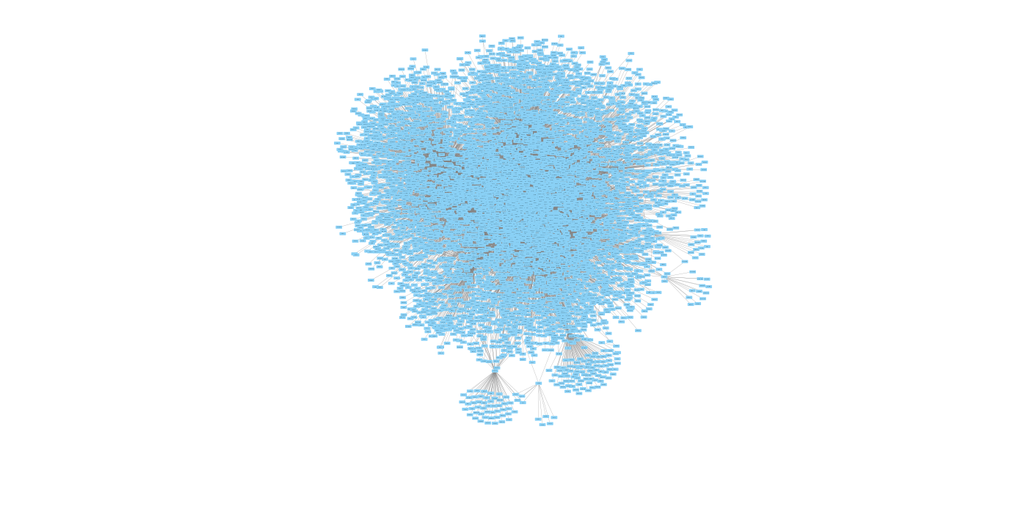

Disease interactome graph.

| X | nodes_degree | nodes_betweenness_centrality | eigen_vector_centrality | closeness_centrality | betweennes_degree_ratio |
| --- | --- | --- | --- | --- | --- |
| MYC | 1956 | 0.3520452 | 0.4743706 | 0.4927457 | 0.0001800 |
| KRAS | 1593 | 0.2766164 | 0.3086325 | 0.4477919 | 0.0001736 |
| TP53 | 1328 | 0.2274370 | 0.2893261 | 0.4759286 | 0.0001713 |
| CTNNB1 | 708 | 0.0858398 | 0.1839057 | 0.4512143 | 0.0001212 |
| CDH1 | 657 | 0.0823632 | 0.1306841 | 0.4133892 | 0.0001254 |
| HRAS | 633 | 0.0791818 | 0.1184252 | 0.4287654 | 0.0001251 |
| IKBKG | 393 | 0.0657733 | 0.0638395 | 0.4120947 | 0.0001674 |
| MAPK1 | 330 | 0.0466317 | 0.0734102 | 0.4473479 | 0.0001413 |
| STAT3 | 294 | 0.0399930 | 0.0567409 | 0.3977208 | 0.0001360 |
| PML | 276 | 0.0359068 | 0.0755400 | 0.4489056 | 0.0001301 |
| TK1 | 204 | 0.0351768 | 0.0354053 | 0.3988005 | 0.0001724 |
| TNF | 301 | 0.0304197 | 0.0533508 | 0.3549275 | 0.0001011 |
| RB1 | 259 | 0.0275146 | 0.0640836 | 0.4109954 | 0.0001062 |
| MAPK3 | 243 | 0.0274794 | 0.0555375 | 0.4181228 | 0.0001131 |
| CCNDBP1 | 131 | 0.0270992 | 0.0078218 | 0.3352261 | 0.0002069 |
| PRDX1 | 217 | 0.0230300 | 0.0479814 | 0.3914121 | 0.0001061 |
| TGFB1 | 258 | 0.0228321 | 0.0554258 | 0.3541912 | 0.0000885 |
| CCND1 | 224 | 0.0194292 | 0.0581923 | 0.3814153 | 0.0000867 |
| GSTP1 | 147 | 0.0190903 | 0.0293582 | 0.3828717 | 0.0001299 |
| BCL2L1 | 181 | 0.0187980 | 0.0459919 | 0.4063425 | 0.0001039 |
| CXCL9 | 74 | 0.0165921 | 0.0010691 | 0.3052871 | 0.0002242 |
| MET | 127 | 0.0158673 | 0.0429730 | 0.4194834 | 0.0001249 |
| GJB1 | 76 | 0.0151805 | 0.0059988 | 0.3325962 | 0.0001997 |
| BCL2 | 113 | 0.0133933 | 0.0417643 | 0.4377685 | 0.0001185 |
| SOCS1 | 148 | 0.0126367 | 0.0336162 | 0.3737870 | 0.0000854 |
| ENO2 | 108 | 0.0124763 | 0.0129452 | 0.3322988 | 0.0001155 |
| FAS | 111 | 0.0123463 | 0.0193346 | 0.3585131 | 0.0001112 |
| SPP1 | 92 | 0.0119589 | 0.0099339 | 0.3318624 | 0.0001300 |
| TSC22D1 | 93 | 0.0095640 | 0.0160543 | 0.3586352 | 0.0001028 |
| TNFRSF10B | 74 | 0.0090746 | 0.0086328 | 0.3326663 | 0.0001226 |